# Home Loan credit risk prediction: DataPreparation and Modeling

## Determine which Id belongs to which cluster and add this data to the df2.scale in form of cluster number:1, 2, or 3 per each id

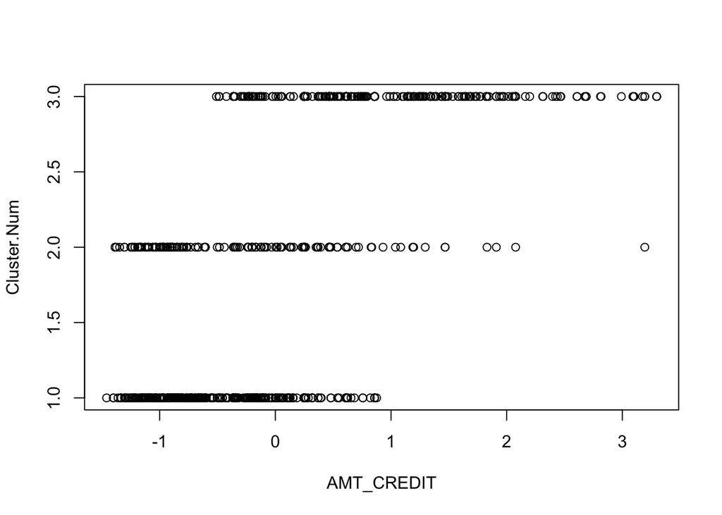

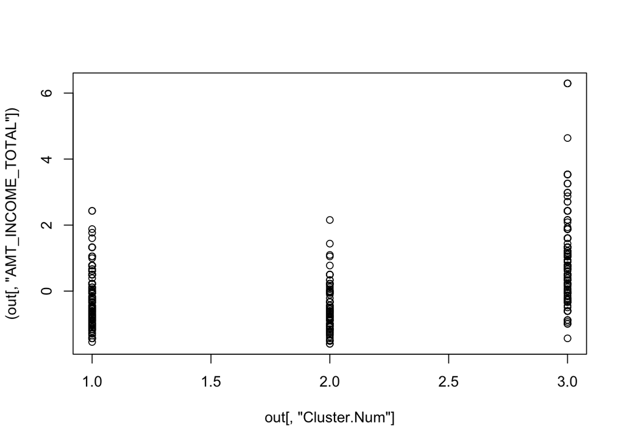

## Correlation matrix for most variables

AMT_ANNUITY/AMT_CREDIT are highly correlated

```r
# ensure the results are repeatable
set.seed(7)
# calculate correlation matrix
correlationMatrix <- cor(target.zero[,classes=="numeric"])#3:64
# summarize the correlation matrix
print(correlationMatrix)
```

```
##                            AMT_INCOME_TOTAL  AMT_CREDIT  AMT_ANNUITY
## AMT_INCOME_TOTAL                 1.00000000  0.40512047  0.480306928
## AMT_CREDIT                       0.40512047  1.00000000  0.753941262
## AMT_ANNUITY                      0.48030693  0.75394126  1.000000000
## REGION_POPULATION_RELATIVE       0.07008894  0.06577963  0.054534966
## DAYS_BIRTH                       0.10801286 -0.07175819 -0.003494938
## DAYS_EMPLOYED                   -0.22550257 -0.10746233 -0.124305935
## DAYS_REGISTRATION                0.09518579 -0.01257973  0.032012065
## DAYS_ID_PUBLISH                  0.00754432 -0.01277051  0.028518641
## DAYS_LAST_PHONE_CHANGE           0.00334633 -0.06536417 -0.023843044
##                            REGION_POPULATION_RELATIVE   DAYS_BIRTH
## AMT_INCOME_TOTAL                           0.07008894  0.108012857
## AMT_CREDIT                                 0.06577963 -0.071758194
## AMT_ANNUITY                                0.05453497 -0.003494938
## REGION_POPULATION_RELATIVE                 1.00000000 -0.033625472
## DAYS_BIRTH                                -0.03362547  1.000000000
## DAYS_EMPLOYED                             -0.04217866 -0.600379547
## DAYS_REGISTRATION                         -0.02594799  0.361581124
## DAYS_ID_PUBLISH                            0.07310748  0.244085021
## DAYS_LAST_PHONE_CHANGE                    -0.00117684  0.076141716
##                            DAYS_EMPLOYED DAYS_REGISTRATION DAYS_ID_PUBLISH
## AMT_INCOME_TOTAL             -0.22550257        0.09518579      0.00754432
## AMT_CREDIT                   -0.10746233       -0.01257973     -0.01277051
## AMT_ANNUITY                  -0.12430594        0.03201207      0.02851864
## REGION_POPULATION_RELATIVE   -0.04217866       -0.02594799      0.07310748
## DAYS_BIRTH                   -0.60037955        0.36158112      0.24408502
## DAYS_EMPLOYED                 1.00000000       -0.20196697     -0.28782032
## DAYS_REGISTRATION            -0.20196697        1.00000000      0.08744739
## DAYS_ID_PUBLISH              -0.28782032        0.08744739      1.00000000
## DAYS_LAST_PHONE_CHANGE        0.03776367        0.03069175      0.09008735
##                            DAYS_LAST_PHONE_CHANGE
## AMT_INCOME_TOTAL                       0.00334633
## AMT_CREDIT                            -0.06536417
## AMT_ANNUITY                           -0.02384304
## REGION_POPULATION_RELATIVE            -0.00117684
## DAYS_BIRTH                             0.07614172
## DAYS_EMPLOYED                          0.03776367
## DAYS_REGISTRATION                      0.03069175
## DAYS_ID_PUBLISH                        0.09008735
## DAYS_LAST_PHONE_CHANGE                 1.00000000
```

```r
# find attributes that are highly corrected (ideally >0.75)
highlyCorrelated <- findCorrelation(correlationMatrix, cutoff=0.5)
# print indexes of highly correlated attributes
print(highlyCorrelated) #
```

```
## [1] 6 3
```

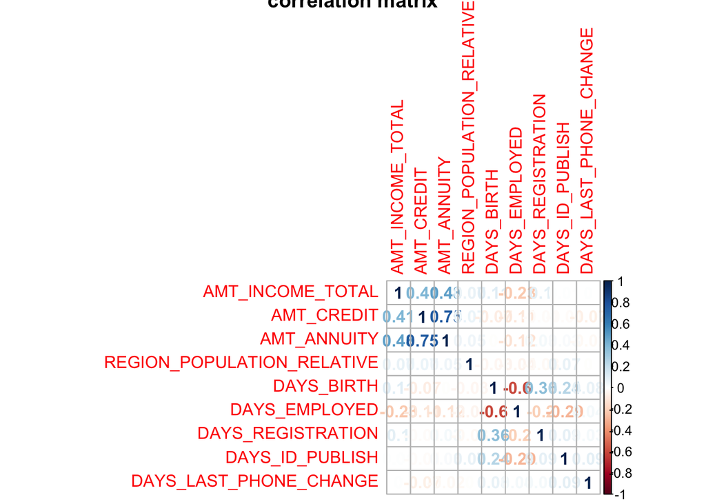

##Rank features by importance using the caret r packageR supervised feature selection

```r
# estimate variable importance
importance <- varImp(model, scale=FALSE)
# summarize importance
print(importance)
```

```
## ROC curve variable importance
##
##   only 20 most important variables shown (out of 62)
##
##                             Importance
## DAYS_ID_PUBLISH                 0.6095
## DAYS_BIRTH                      0.6043
## DAYS_EMPLOYED                   0.5766
## REGION_RATING_CLIENT            0.5665
## REGION_RATING_CLIENT_W_CITY     0.5619
## FLAG_OWN_REALTY                 0.5606
## DAYS_LAST_PHONE_CHANGE          0.5593
## EMERGENCYSTATE_MODE             0.5457
## REG_CITY_NOT_LIVE_CITY          0.5451
## DAYS_REGISTRATION               0.5445
## AMT_CREDIT                      0.5438
## FONDKAPREMONT_MODE              0.5436
## REG_CITY_NOT_WORK_CITY          0.5432
## NAME_EDUCATION_TYPE             0.5409
## CNT_FAM_MEMBERS                 0.5399
## HOUSETYPE_MODE                  0.5393
## WALLSMATERIAL_MODE              0.5353
## REGION_POPULATION_RELATIVE      0.5309
## FLAG_WORK_PHONE                 0.5290
## FLAG_EMAIL                      0.5265
```

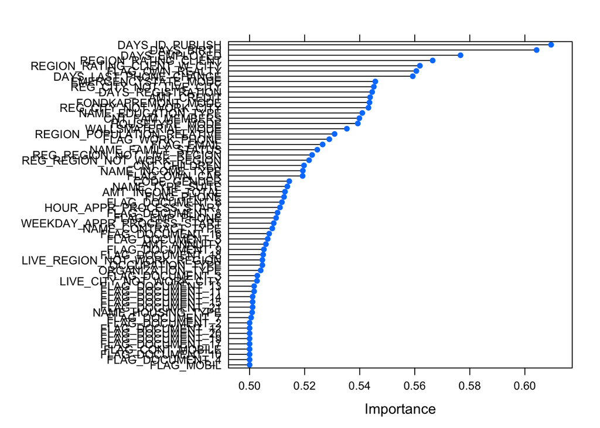

##Feature selection (dimensionality reduction) with PCA

```r
summary.pca <- summary(l.pca)
#head(l.pca)
#str(l.pca)
#distance <- dist(z.pca)
#str(distance)

#percentage of variance captured by PCA
pca_pr <- round(100*summary.pca$importance[2, ], digits = 1)
pca_pr
```

```
##  PC1  PC2  PC3  PC4  PC5  PC6  PC7  PC8  PC9
## 25.0 20.8 11.6 11.1  9.8  8.3  6.9  3.9  2.7
```

```r
#axis labels
pc_lab <- paste0(names(pca_pr), " (", pca_pr, "%)")
pc_lab
```

```
## [1] "PC1 (25%)"   "PC2 (20.8%)" "PC3 (11.6%)" "PC4 (11.1%)" "PC5 (9.8%)"
## [6] "PC6 (8.3%)"  "PC7 (6.9%)"  "PC8 (3.9%)"  "PC9 (2.7%)"
```

## PCA biplot

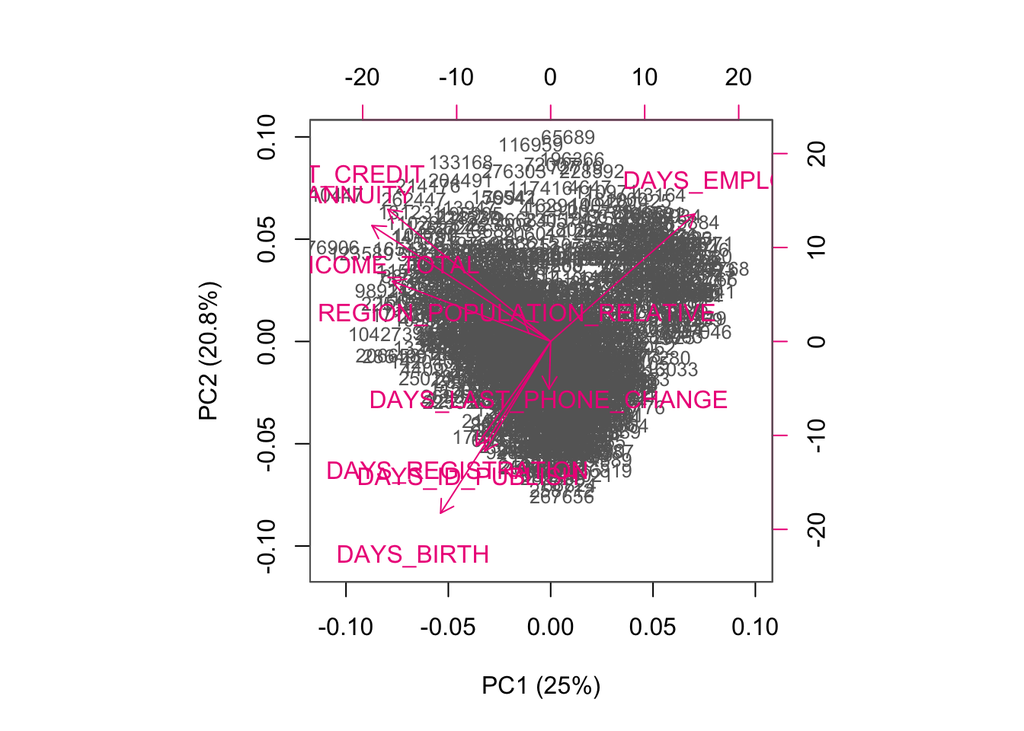

##PCA with MLBench

```r
preprocParam <- preProcess(loan.data.numeric, method=c("center", "scale", "pca"))
# summarize preprocessed
print(preprocParam)
```

```
## Created from 1000 samples and 9 variables
##
## Pre-processing:
##   - centered (9)
##   - ignored (0)
##   - principal component signal extraction (9)
##   - scaled (9)
##
## PCA needed 8 components to capture 95 percent of the variance
```

```r
# transform the data
tran <- predict(preprocParam, loan.data.all2.no.na)
# summarize the transformed dataset
summary(tran)
```

```
##    SK_ID_CURR     TARGET        NAME_CONTRACT_TYPE CODE_GENDER
##  Min.   :100598   0:913   Cash loans     :893      F  :670
##  1st Qu.:190065   1: 87   Revolving loans:107      M  :330
##  Median :272278                                    XNA:  0
##  Mean   :276708
##  3rd Qu.:366112
##  Max.   :456075
##
##  FLAG_OWN_CAR FLAG_OWN_REALTY  CNT_CHILDREN          NAME_TYPE_SUITE
##  N:643        N:306           Min.   :0.000   Unaccompanied  :792
##  Y:357        Y:694           1st Qu.:0.000   Family         :148
##                               Median :0.000   Spouse, partner: 34
##                               Mean   :0.415   Children       : 12
##                               3rd Qu.:1.000   Other_A        :  6
##                               Max.   :4.000                  :  5
##                                               (Other)        :  3
##              NAME_INCOME_TYPE                    NAME_EDUCATION_TYPE
##  Working             :546     Academic degree              :  0
##  Commercial associate:216     Higher education             :246
##  Pensioner           :167     Incomplete higher            : 29
##  State servant       : 70     Lower secondary              :  8
##  Businessman         :  1     Secondary / secondary special:717
##  Maternity leave     :  0
##  (Other)             :  0
##             NAME_FAMILY_STATUS           NAME_HOUSING_TYPE   FLAG_MOBIL
##  Civil marriage      :110      Co-op apartment    :  5     Min.   :1
##  Married             :639      House / apartment  :887     1st Qu.:1
##  Separated           : 65      Municipal apartment: 33     Median :1
##  Single / not married:139      Office apartment   :  8     Mean   :1
##  Widow               : 47      Rented apartment   : 24     3rd Qu.:1
##                                With parents       : 43     Max.   :1
##
##  FLAG_EMP_PHONE  FLAG_WORK_PHONE FLAG_CONT_MOBILE   FLAG_PHONE
##  Min.   :0.000   Min.   :0.0     Min.   :1        Min.   :0.000
##  1st Qu.:1.000   1st Qu.:0.0     1st Qu.:1        1st Qu.:0.000
##  Median :1.000   Median :0.0     Median :1        Median :0.000
##  Mean   :0.833   Mean   :0.2     Mean   :1        Mean   :0.276
##  3rd Qu.:1.000   3rd Qu.:0.0     3rd Qu.:1        3rd Qu.:1.000
##  Max.   :1.000   Max.   :1.0     Max.   :1        Max.   :1.000
##
```

[output cut: 97 more lines]

```
##  Min.   :-5.17353   Min.   :-3.2793   Min.   :-2.72024   Min.   :-3.1029
##  1st Qu.:-0.95683   1st Qu.:-1.0318   1st Qu.:-0.71327   1st Qu.:-0.6582
##  Median :-0.02675   Median :-0.1024   Median :-0.06679   Median : 0.1304
##  Mean   : 0.00000   Mean   : 0.0000   Mean   : 0.00000   Mean   : 0.0000
##  3rd Qu.: 0.92730   3rd Qu.: 0.9692   3rd Qu.: 0.71991   3rd Qu.: 0.7140
##  Max.   : 3.85518   Max.   : 4.3271   Max.   : 3.31687   Max.   : 2.1453
##
##       PC5               PC6               PC7                PC8
##  Min.   :-2.7035   Min.   :-2.7528   Min.   :-5.21673   Min.   :-2.20673
##  1st Qu.:-0.6582   1st Qu.:-0.5817   1st Qu.:-0.40233   1st Qu.:-0.42052
##  Median :-0.0425   Median :-0.0681   Median : 0.07383   Median :-0.04053
##  Mean   : 0.0000   Mean   : 0.0000   Mean   : 0.00000   Mean   : 0.00000
##  3rd Qu.: 0.6300   3rd Qu.: 0.6211   3rd Qu.: 0.49910   3rd Qu.: 0.39931
##  Max.   : 2.9984   Max.   : 3.0462   Max.   : 2.15281   Max.   : 1.52659
##
```

## Feature selection with unsupervised Multiple Correspondence Analysis (MCA)

income type occupation type contribute to overall variability

```r
mca <- MCA(loan.selected, graph = FALSE)
#length(loan.data.all2.no.na)
# summary of the model
summary(mca)
```

```
##
## Call:
## MCA(X = loan.selected, graph = FALSE)
##
##
## Eigenvalues
##                        Dim.1   Dim.2   Dim.3   Dim.4   Dim.5   Dim.6
## Variance               0.227   0.180   0.132   0.117   0.110   0.105
## % of var.              3.111   2.464   1.805   1.606   1.508   1.433
## Cumulative % of var.   3.111   5.575   7.380   8.987  10.494  11.928
##                        Dim.7   Dim.8   Dim.9  Dim.10  Dim.11  Dim.12
## Variance               0.104   0.100   0.099   0.097   0.095   0.094
## % of var.              1.418   1.369   1.349   1.322   1.297   1.286
## Cumulative % of var.  13.346  14.714  16.064  17.386  18.683  19.969
##                       Dim.13  Dim.14  Dim.15  Dim.16  Dim.17  Dim.18
## Variance               0.093   0.093   0.091   0.089   0.089   0.088
## % of var.              1.275   1.267   1.246   1.219   1.215   1.206
## Cumulative % of var.  21.244  22.511  23.757  24.976  26.190  27.397
##                       Dim.19  Dim.20  Dim.21  Dim.22  Dim.23  Dim.24
## Variance               0.086   0.083   0.083   0.083   0.082   0.081
## % of var.              1.173   1.139   1.131   1.129   1.117   1.101
## Cumulative % of var.  28.569  29.708  30.839  31.968  33.085  34.186
##                       Dim.25  Dim.26  Dim.27  Dim.28  Dim.29  Dim.30
## Variance               0.080   0.079   0.078   0.078   0.076   0.075
## % of var.              1.093   1.079   1.066   1.063   1.042   1.031
## Cumulative % of var.  35.279  36.358  37.424  38.488  39.530  40.561
##                       Dim.31  Dim.32  Dim.33  Dim.34  Dim.35  Dim.36
## Variance               0.075   0.074   0.073   0.072   0.072   0.070
## % of var.              1.019   1.012   1.003   0.990   0.982   0.964
## Cumulative % of var.  41.580  42.593  43.596  44.586  45.568  46.532
##                       Dim.37  Dim.38  Dim.39  Dim.40  Dim.41  Dim.42
## Variance               0.070   0.070   0.069   0.069   0.069   0.067
## % of var.              0.959   0.953   0.943   0.941   0.937   0.919
## Cumulative % of var.  47.491  48.444  49.386  50.327  51.265  52.184
##                       Dim.43  Dim.44  Dim.45  Dim.46  Dim.47  Dim.48
## Variance               0.067   0.066   0.066   0.065   0.065   0.065
## % of var.              0.911   0.905   0.900   0.894   0.891   0.884
## Cumulative % of var.  53.095  54.000  54.900  55.794  56.685  57.569
##                       Dim.49  Dim.50  Dim.51  Dim.52  Dim.53  Dim.54
## Variance               0.064   0.064   0.064   0.063   0.063   0.063
```

[output cut: 103 more lines]

```
## NAME_TYPE_SUITE_           2.863 |
## NAME_TYPE_SUITE_Children   0.916 |
##
## Categorical variables (eta2)
##                            Dim.1 Dim.2 Dim.3
## NAME_CONTRACT_TYPE       | 0.003 0.003 0.002 |
## CODE_GENDER              | 0.012 0.130 0.254 |
## FLAG_OWN_CAR             | 0.023 0.136 0.081 |
## FLAG_OWN_REALTY          | 0.000 0.007 0.000 |
## NAME_TYPE_SUITE          | 0.011 0.023 0.020 |
## NAME_INCOME_TYPE         | 0.028 0.802 0.249 |
## NAME_EDUCATION_TYPE      | 0.018 0.051 0.120 |
## NAME_FAMILY_STATUS       | 0.022 0.100 0.036 |
## NAME_HOUSING_TYPE        | 0.025 0.033 0.020 |
## OCCUPATION_TYPE          | 0.058 0.597 0.653 |
```

```r
summary(loan.selected)
```

```
##        NAME_CONTRACT_TYPE CODE_GENDER FLAG_OWN_CAR FLAG_OWN_REALTY
##  Cash loans     :893      F  :670     N:643        N:306
##  Revolving loans:107      M  :330     Y:357        Y:694
##                           XNA:  0
##
##
##
##
##         NAME_TYPE_SUITE             NAME_INCOME_TYPE
##  Unaccompanied  :792    Working             :546
##  Family         :148    Commercial associate:216
##  Spouse, partner: 34    Pensioner           :167
##  Children       : 12    State servant       : 70
##  Other_A        :  6    Businessman         :  1
##                 :  5    Maternity leave     :  0
##  (Other)        :  3    (Other)             :  0
##                     NAME_EDUCATION_TYPE            NAME_FAMILY_STATUS
##  Academic degree              :  0      Civil marriage      :110
##  Higher education             :246      Married             :639
##  Incomplete higher            : 29      Separated           : 65
##  Lower secondary              :  8      Single / not married:139
##  Secondary / secondary special:717      Widow               : 47
##
##
##            NAME_HOUSING_TYPE    OCCUPATION_TYPE WEEKDAY_APPR_PROCESS_START
##  Co-op apartment    :  5                :319    FRIDAY   :175
##  House / apartment  :887     Laborers   :198    MONDAY   :149
##  Municipal apartment: 33     Sales staff: 98    SATURDAY :121
##  Office apartment   :  8     Core staff : 80    SUNDAY   : 43
##  Rented apartment   : 24     Managers   : 73    THURSDAY :165
##  With parents       : 43     Drivers    : 54    TUESDAY  :172
##                              (Other)    :178    WEDNESDAY:175
##               ORGANIZATION_TYPE             FONDKAPREMONT_MODE
##  Business Entity Type 3:215                          :692
##  XNA                   :167     not specified        : 16
##  Self-employed         :125     org spec account     : 19
##  Other                 : 59     reg oper account     :241
##  Medicine              : 41     reg oper spec account: 32
##  Business Entity Type 2: 36
##  (Other)               :357
##           HOUSETYPE_MODE    WALLSMATERIAL_MODE EMERGENCYSTATE_MODE
##                  :513                :519         :482
##  block of flats  :477    Stone, brick:221      No :513
##  specific housing:  6    Panel       :204      Yes:  5
##  terraced house  :  4    Block       : 25
##                          Wooden      : 16
##                          Others      :  6
##                          (Other)     :  9
```

## Visualize the dataset

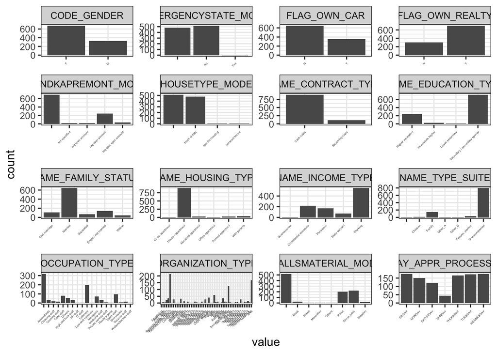

## Visualize MCA

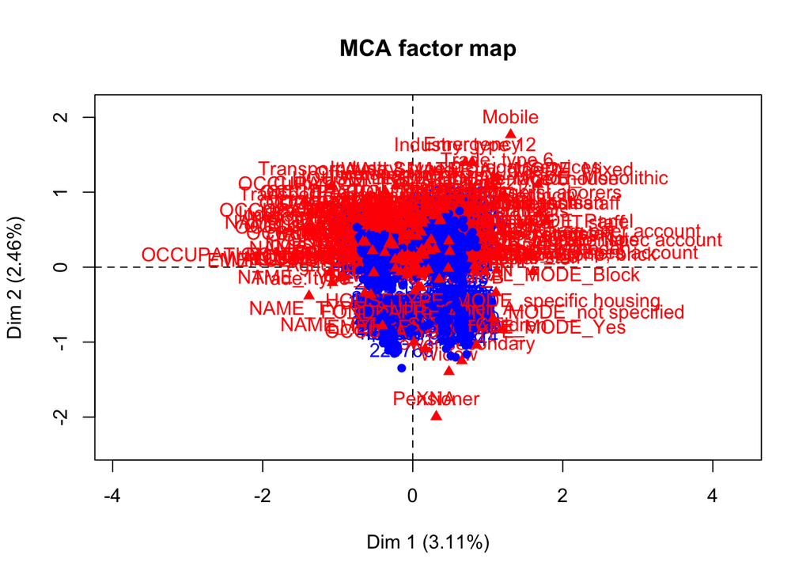

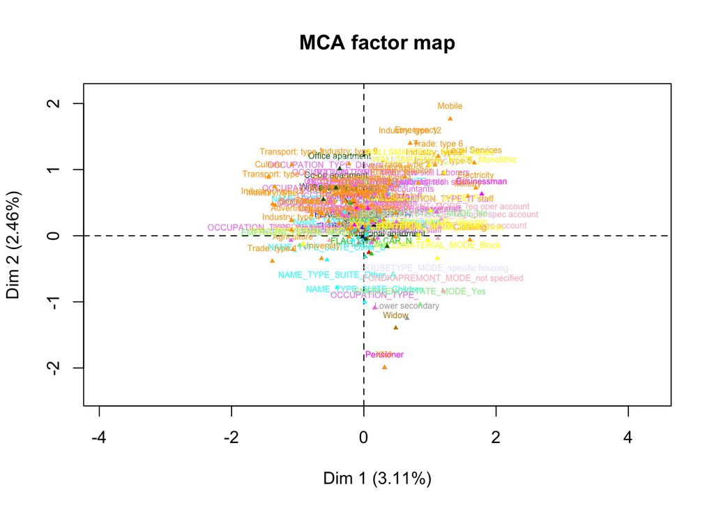

## Supervised feature selection with Caret prepare training scheme

## Summarize importance Caret feature selection

```r
print(importance)
```

```
## ROC curve variable importance
##
##   only 20 most important variables shown (out of 62)
##
##                             Importance
## DAYS_ID_PUBLISH                 0.6095
## DAYS_BIRTH                      0.6043
## DAYS_EMPLOYED                   0.5766
## REGION_RATING_CLIENT            0.5665
## REGION_RATING_CLIENT_W_CITY     0.5619
## FLAG_OWN_REALTY                 0.5606
## DAYS_LAST_PHONE_CHANGE          0.5593
## EMERGENCYSTATE_MODE             0.5457
## REG_CITY_NOT_LIVE_CITY          0.5451
## DAYS_REGISTRATION               0.5445
## AMT_CREDIT                      0.5438
## FONDKAPREMONT_MODE              0.5436
## REG_CITY_NOT_WORK_CITY          0.5432
## NAME_EDUCATION_TYPE             0.5409
## CNT_FAM_MEMBERS                 0.5399
## HOUSETYPE_MODE                  0.5393
## WALLSMATERIAL_MODE              0.5353
## REGION_POPULATION_RELATIVE      0.5309
## FLAG_WORK_PHONE                 0.5290
## FLAG_EMAIL                      0.5265
```

## Plot importance

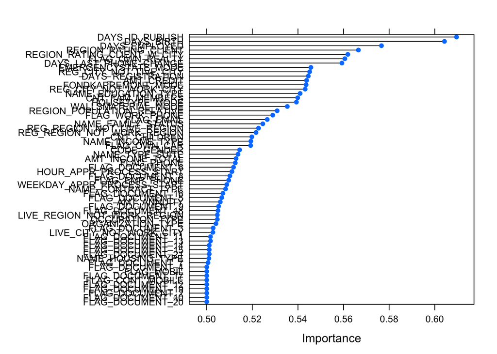

##Supervised Recursive Feature Elimination (RFE) supervised model

## Summarize the results

```r
print(results)
```

```
##
## Recursive feature selection
##
## Outer resampling method: Cross-Validated (3 fold)
##
## Resampling performance over subset size:
##
##  Variables   RMSE  Rsquared   MAE RMSESD RsquaredSD MAESD Selected
##          2 108075 0.0008572 91168   5333   0.001054  3911
##          3 105485 0.0019391 90296   3980   0.002341  3010
##          4 103277 0.0014661 88818   1374   0.002426  2232
##          5 102731 0.0022526 88552   1551   0.003482  2564        *
##          6 105364 0.0042009 90205   2705   0.006290  3180
##          7 104667 0.0062027 89929   2674   0.010230  2957
##          8 104019 0.0050490 89198   1650   0.005209  2329
##          9 104772 0.0069480 89667   1769   0.005543  1713
##
## The top 5 variables (out of 5):
##    AMT_ANNUITY, AMT_CREDIT, AMT_INCOME_TOTAL, NAME_CONTRACT_TYPE, CNT_CHILDREN
```

```r
# list the chosen features
predictors(results)
```

```
## [1] "AMT_ANNUITY"        "AMT_CREDIT"         "AMT_INCOME_TOTAL"
## [4] "NAME_CONTRACT_TYPE" "CNT_CHILDREN"
```

## Plot the results

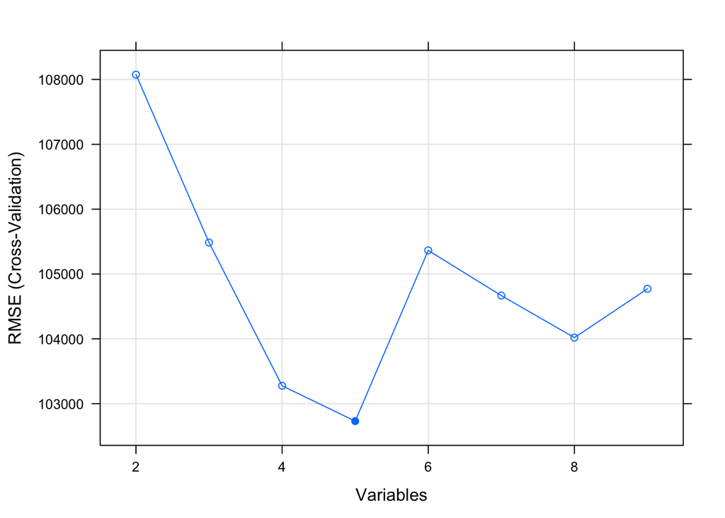

##Creating levels

## Checking the categories for each variable

## Stacking ensemble

```r
summary(r)
```

```
##
## Call:
## summary.resamples(object = r)
##
## Models: rpart, knn
## Number of resamples: 9
##
## Accuracy
##            Min.   1st Qu.    Median      Mean   3rd Qu.      Max. NA's
## rpart 0.9129129 0.9129129 0.9129129 0.9129998 0.9131737 0.9131737    0
## knn   0.9129129 0.9129129 0.9129129 0.9129998 0.9131737 0.9131737    0
##
## Kappa
##       Min. 1st Qu. Median Mean 3rd Qu. Max. NA's
## rpart    0       0      0    0       0    0    0
## knn      0       0      0    0       0    0    0
```

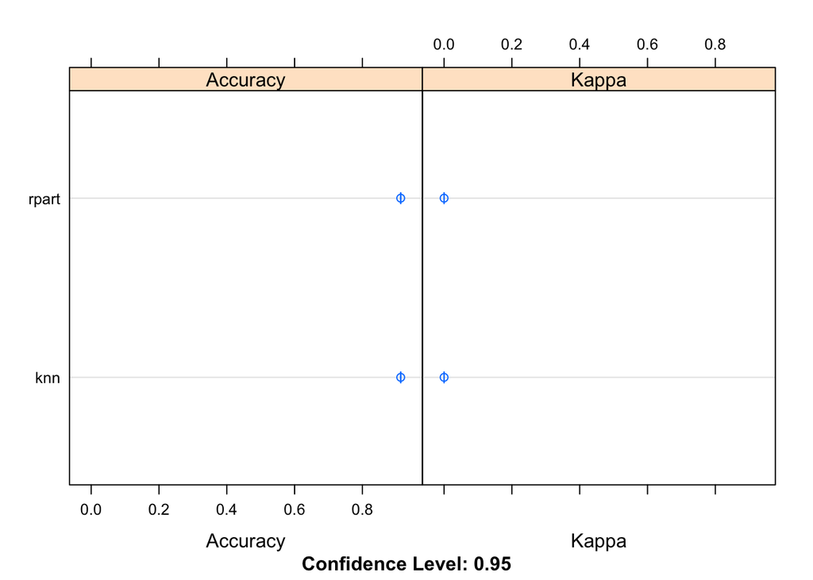

## Correlation stacking ensemble

```r
modelCor(r)
```

```
##       rpart knn
## rpart     1   1
## knn       1   1
```

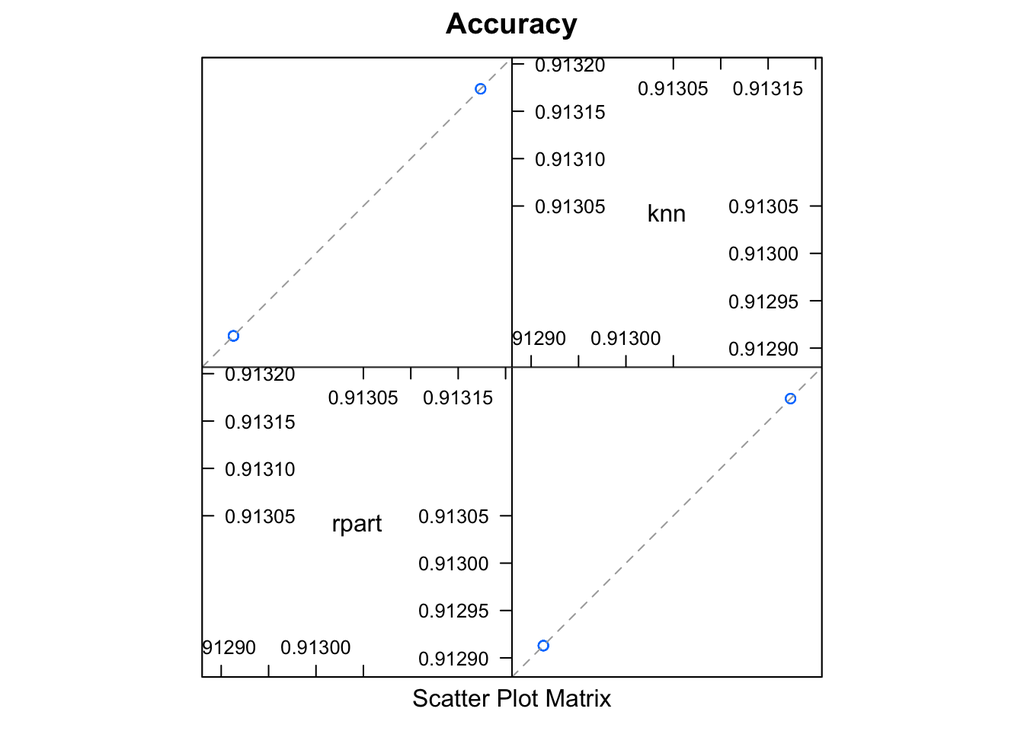

```r
splom(r)
```

## Stack using glm

## Stack using Random Forest

## Ensamble bagging CART and Random Forest

## Summarize results Bagged CART and Random Forest

```r
bagging_results <- resamples(list(treebag=fit.treebag, rf=fit.rf))
summary(bagging_results)
```

```
##
## Call:
## summary.resamples(object = bagging_results)
##
## Models: treebag, rf
## Number of resamples: 9
##
## Accuracy
##              Min.   1st Qu.    Median      Mean   3rd Qu.      Max. NA's
## treebag 0.9129129 0.9129129 0.9129129 0.9129998 0.9131737 0.9131737    0
## rf      0.9129129 0.9129129 0.9129129 0.9129998 0.9131737 0.9131737    0
##
## Kappa
##         Min. 1st Qu. Median Mean 3rd Qu. Max. NA's
## treebag    0       0      0    0       0    0    0
## rf         0       0      0    0       0    0    0
```

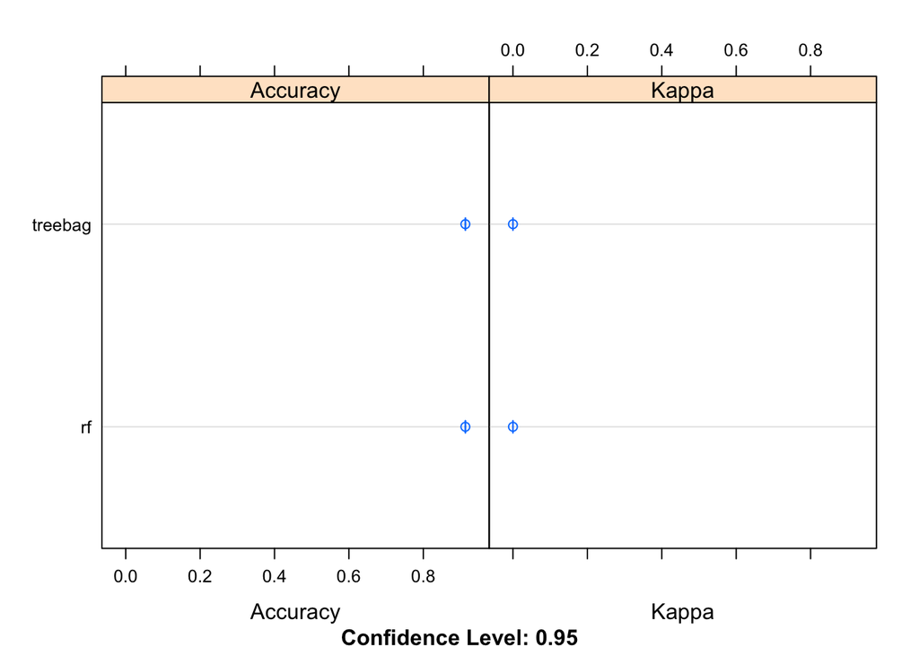

```r
dotplot(bagging_results)
```

##Simply rpart (submitted to Kaggle) Needs improvement and balancing of several predictors

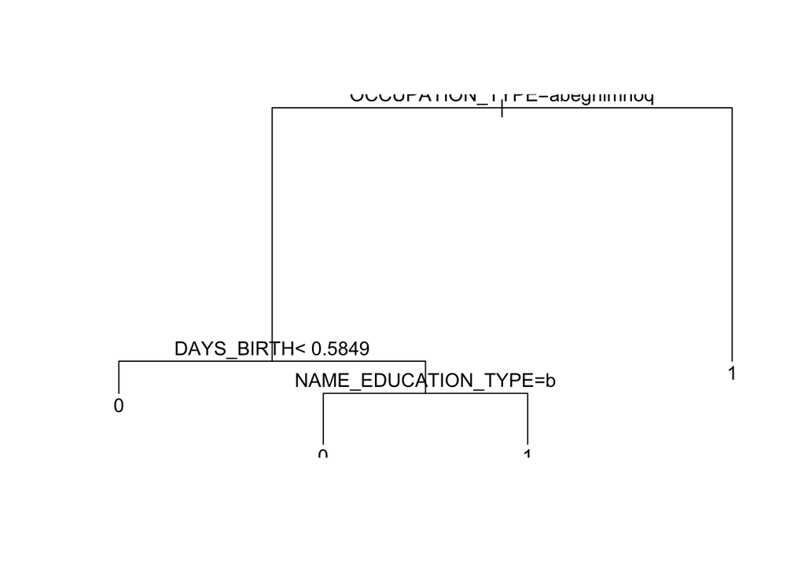

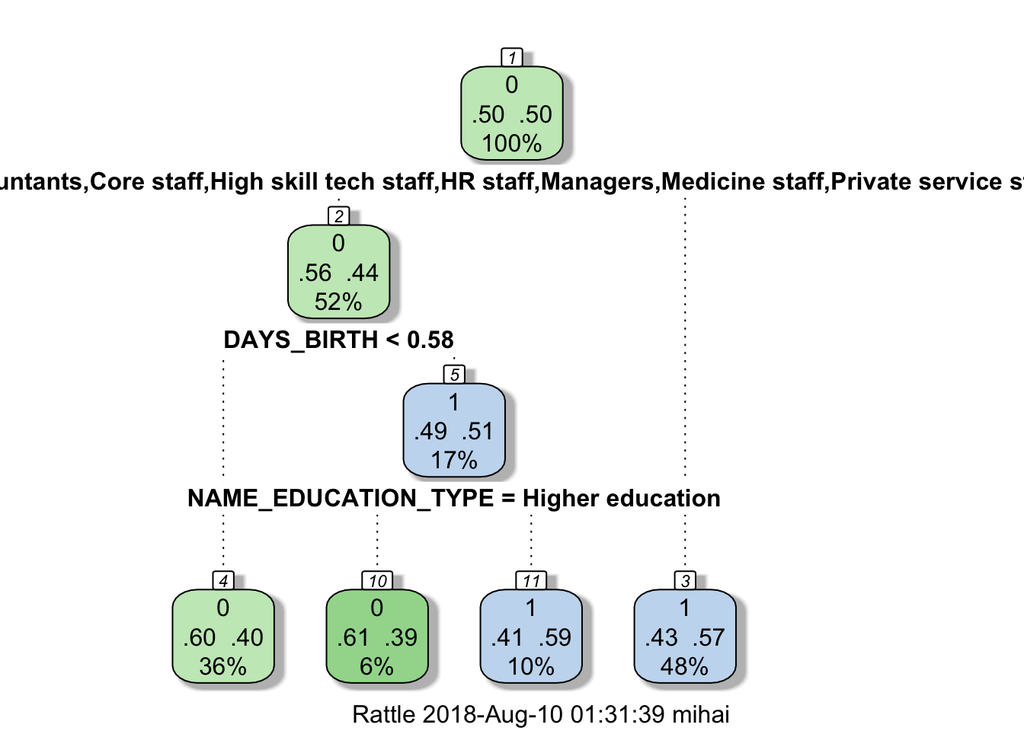

```r
#rpart the decision tree
loan.tree <- rpart(TARGET ~ ., data = data.balanced, method = "class")

# Visualize the decision tree using plot() and text()
plot(loan.tree)
text(loan.tree)
```

## Kaggle: - Preparing the solutions and CSV file for the submission

# Making predictions on the test set

```r
my_prediction <- predict(loan.tree, newdata = test.data, type = "class")

my_solution <- data.frame(SK_ID_CURR = test.data$SK_ID_CURR, TARGET = my_prediction)

nrow(my_solution)
```

```
## [1] 48744
```

```r
write.csv(my_solution, file = "group5.csv", row.names = FALSE)
```

## Pifalls:

- merging data before or after feature selection/dimensionality reduction
- dealing with NA values: column wise or drop sample
- dealing with outliers for numerical variables